# Month of interview

# 1 Description of DataSchema variable

The description of harmonised variable is the following:

- Short name: `mintw`
- Variable label: `month of interview`
- Domain: `Other administrative variables`
- Value type: `Categorical`
- Categories:

| **Code** | **Category Label** |
| --- | --- |
| 1 | january |
| 2 | february |
| 3 | march |
| 4 | april |
| 5 | may |
| 6 | june |
| 7 | july |
| 8 | august |
| 9 | september |
| 10 | october |
| 11 | november |
| 12 | december |

- Category missings:

| **Code** | **Category Label** |
| --- | --- |
| 991 | CAPI/interviewer error |
| 992 | Impute |
| 993 | Disable to measure |
| 994 | Not attempt/not done |
| 995 | Does not answer |
| 996 | Not applicable |
| 997 | Refuse |
| 998 | Do not know |
| 999 | Missing |

# 2 Data process

## 2.1 England

### 2.1.1 Wave 1

#### 2.1.1.1 Study-specific variable description

The study-specific variable elected to be harmonised is:

- Name: `iintdatm`
- Label: `interview month - individual interview`
- Type of variable: `countinous`

```
## $values_table
##                  1      2      3       4       5       6       7       8
## Frequency  1108.00 338.00 162.00 1392.00 1351.00 1279.00 2109.00 1433.00
## Percentage    9.16   2.79   1.34   11.51   11.17   10.57   17.43   11.84
##                  9     10     11     12
## Frequency  1237.00 635.00 475.00 580.00
## Percentage   10.22   5.25   3.93   4.79
##
## $n_table
##      Sample size Missing values
## [1,]       12099              0
```

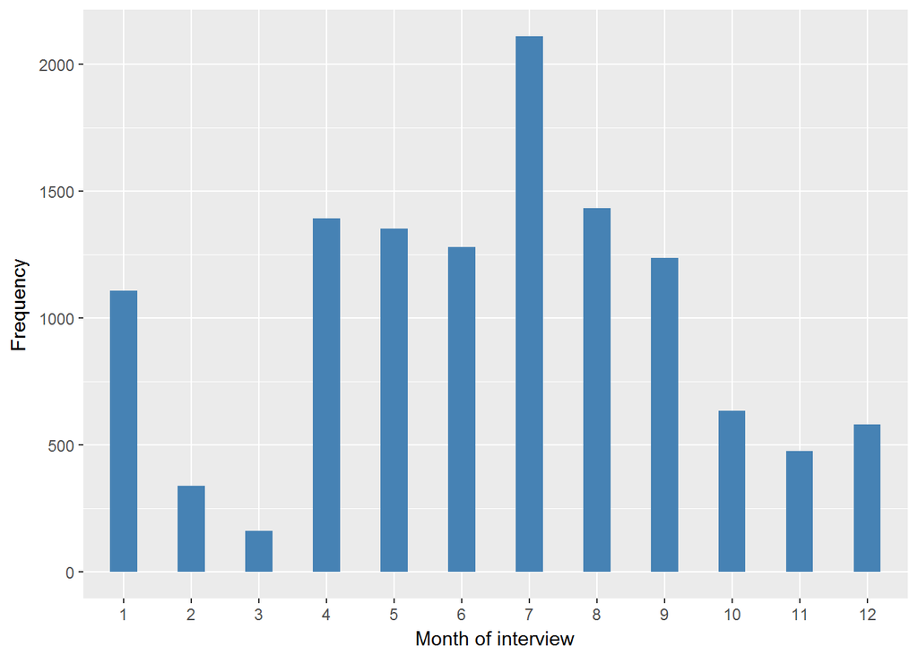

#### 2.1.1.2 Harmonisation algorithm

The harmonized variable is the same of the study-specific variable but the missing values have to be recoded as follows:

- `NA into 999`

**R script:**

```r
ELSA_ds_w1 <- tibble(id = ELSA_w1_minter$id)
ELSA_ds_w1$mintw <- car::recode(ELSA_w1_minter$iintdatm, "NA=999")
ELSA_ds_w1$mintw <- labelled(ELSA_ds_w1$mintw, labels = c(january = 1, february = 2,
    march = 3, april = 4, may = 5, june = 6, july = 7, august = 8, september = 9,
    october = 10, november = 11, december = 12, Missing = 999, `Do not know` = 998,
    Refuse = 997, `Not applicable` = 996, `Does not answer` = 995, `Not attempt not done` = 994,
    `Disable to measure` = 993, Impute = 992, `CAPI interviewer error` = 991))
```

#### 2.1.1.3 Statistics of the new harmonised variable

```
## $values_table
##                  1      2      3       4       5       6       7       8
## Frequency  1108.00 338.00 162.00 1392.00 1351.00 1279.00 2109.00 1433.00
## Percentage    9.16   2.79   1.34   11.51   11.17   10.57   17.43   11.84
##                  9     10     11     12
## Frequency  1237.00 635.00 475.00 580.00
## Percentage   10.22   5.25   3.93   4.79
##
## $missing_values_table
##            991 992 993 994 995 996 997 998 999 NA
## Frequency    0   0   0   0   0   0   0   0   0  0
## Percentage   0   0   0   0   0   0   0   0   0  0
##
## $n_table
##      Sample size Missing values
## [1,]       12099              0
```

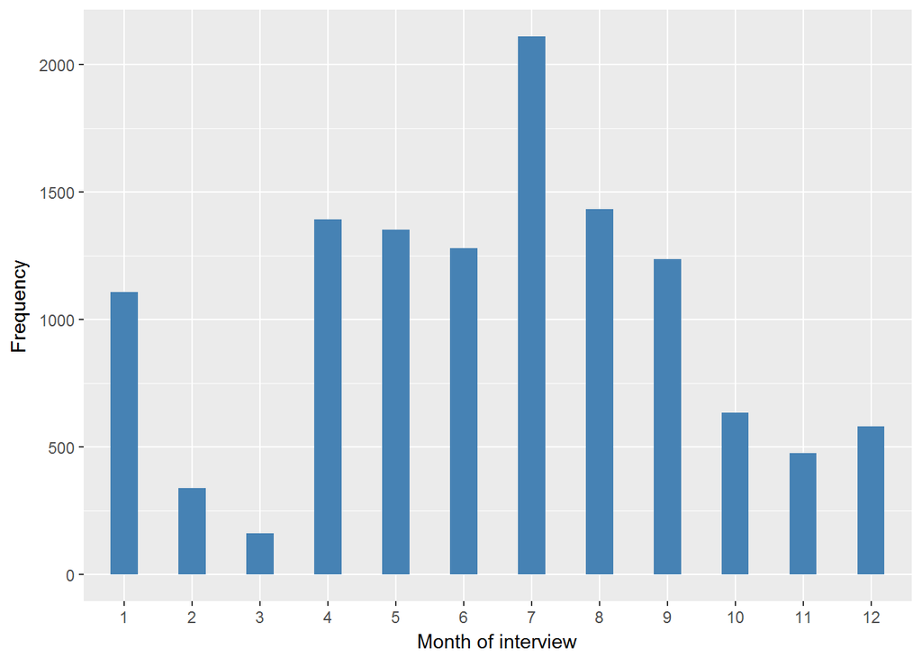

#### 2.1.1.4 Validation

|  | 1 | 2 | 3 | 4 | 5 | 6 | 7 | 8 | 9 | 10 | 11 | 12 |
| --- | --- | --- | --- | --- | --- | --- | --- | --- | --- | --- | --- | --- |
| BeforeH | 1108 | 338 | 162 | 1392 | 1351 | 1279 | 2109 | 1433 | 1237 | 635 | 475 | 580 |
| AfterH | 1108 | 338 | 162 | 1392 | 1351 | 1279 | 2109 | 1433 | 1237 | 635 | 475 | 580 |

### 2.1.2 Wave 2

#### 2.1.2.1 Study-specific variable description

The study-specific variable elected to be harmonised is:

- Name: `iintdatm`
- Label: `interview month - individual interview`
- Type of variable: `countinous`

```
## $values_table
##                  1       2      3      4      5     6      7      8      9
## Frequency  1429.00 1150.00 797.00 657.00 134.00 34.00 643.00 946.00 1066.0
## Percentage   15.15   12.19   8.45   6.97   1.42  0.36   6.82  10.03   11.3
##                 10     11     12
## Frequency  1026.00 955.00 595.00
## Percentage   10.88  10.13   6.31
##
## $n_table
##      Sample size Missing values
## [1,]        9432              0
```

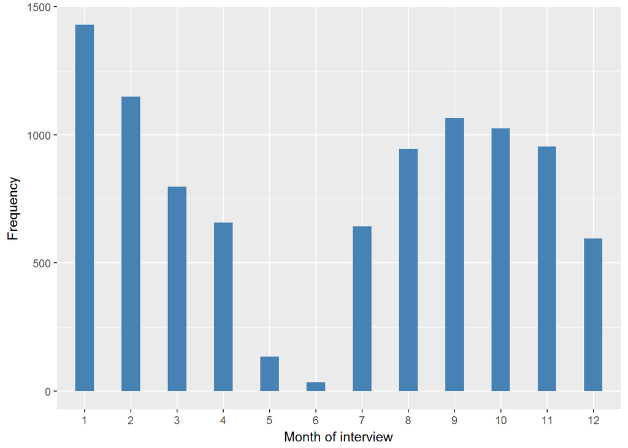

#### 2.1.2.2 Harmonisation algorithm

The harmonized variable is the same of the study-specific variable but the missing values have to be recoded as follows:

- `NA into 999`

**R script:**

```r
ELSA_ds_w2 <- tibble(id = ELSA_w2_minter$id)
ELSA_ds_w2$mintw <- car::recode(ELSA_w2_minter$iintdatm, "NA=999")
ELSA_ds_w2$mintw <- labelled(ELSA_ds_w2$mintw, labels = c(january = 1, february = 2,
    march = 3, april = 4, may = 5, june = 6, july = 7, august = 8, september = 9,
    october = 10, november = 11, december = 12, Missing = 999, `Do not know` = 998,
    Refuse = 997, `Not applicable` = 996, `Does not answer` = 995, `Not attempt not done` = 994,
    `Disable to measure` = 993, Impute = 992, `CAPI interviewer error` = 991))
```

#### 2.1.2.3 Statistics of the new harmonised variable

```
## $values_table
##                  1       2      3      4      5     6      7      8      9
## Frequency  1429.00 1150.00 797.00 657.00 134.00 34.00 643.00 946.00 1066.0
## Percentage   15.15   12.19   8.45   6.97   1.42  0.36   6.82  10.03   11.3
##                 10     11     12
## Frequency  1026.00 955.00 595.00
## Percentage   10.88  10.13   6.31
##
## $missing_values_table
##            991 992 993 994 995 996 997 998 999 NA
## Frequency    0   0   0   0   0   0   0   0   0  0
## Percentage   0   0   0   0   0   0   0   0   0  0
##
## $n_table
##      Sample size Missing values
## [1,]        9432              0
```

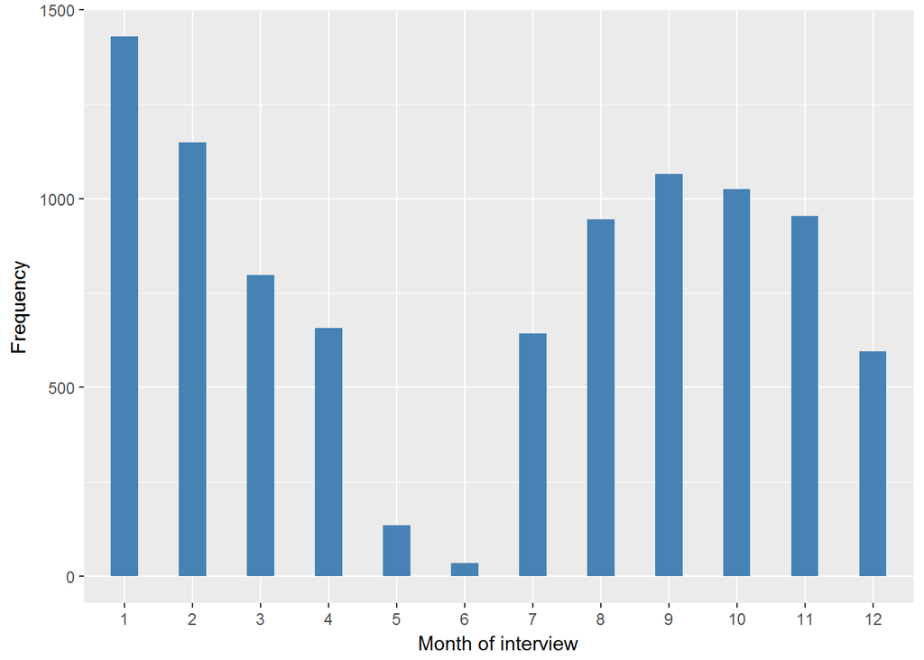

#### 2.1.2.4 Validation

|  | 1 | 2 | 3 | 4 | 5 | 6 | 7 | 8 | 9 | 10 | 11 | 12 |
| --- | --- | --- | --- | --- | --- | --- | --- | --- | --- | --- | --- | --- |
| BeforeH | 1429 | 1150 | 797 | 657 | 134 | 34 | 643 | 946 | 1066 | 1026 | 955 | 595 |
| AfterH | 1429 | 1150 | 797 | 657 | 134 | 34 | 643 | 946 | 1066 | 1026 | 955 | 595 |

### 2.1.3 Wave 3

#### 2.1.3.1 Study-specific variable description

The study-specific variable elected to be harmonised is:

- Name: `iintdatm`
- Label: `interview month - individual interview`
- Type of variable: `countinous`

```
## $values_table
##                 1      2      3     4      5       6      7      8      9
## Frequency  842.00 409.00 142.00 34.00 544.00 1640.00 1114.0 854.00 614.00
## Percentage   8.62   4.19   1.45  0.35   5.57   16.78   11.4   8.74   6.28
##                 10      11    12
## Frequency  1640.00 1430.00 508.0
## Percentage   16.78   14.64   5.2
##
## $n_table
##      Sample size Missing values
## [1,]        9771              0
```

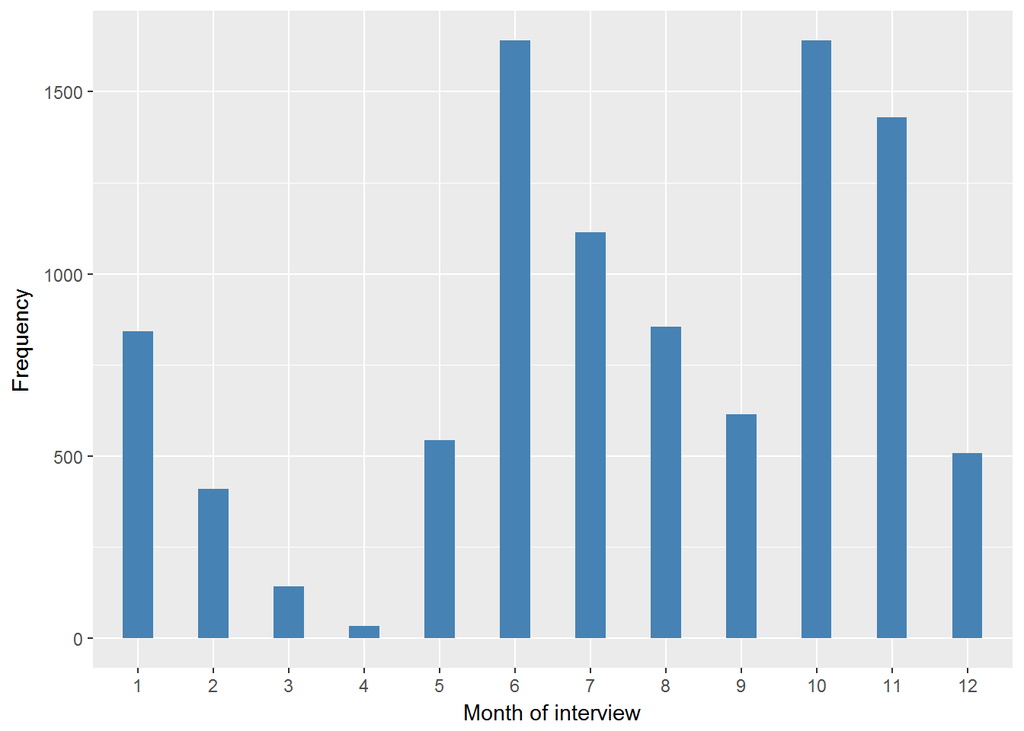

#### 2.1.3.2 Harmonisation algorithm

The harmonized variable is the same of the study-specific variable but the missing values have to be recoded as follows:

- `NA into 999`

**R script:**

```r
ELSA_ds_w3 <- tibble(id = ELSA_w3_yinter$id)
ELSA_ds_w3$mintw <- car::recode(ELSA_w3_yinter$iintdatm, "NA=999")
ELSA_ds_w3$mintw <- labelled(ELSA_ds_w3$mintw, labels = c(january = 1, february = 2,
    march = 3, april = 4, may = 5, june = 6, july = 7, august = 8, september = 9,
    october = 10, november = 11, december = 12, Missing = 999, `Do not know` = 998,
    Refuse = 997, `Not applicable` = 996, `Does not answer` = 995, `Not attempt not done` = 994,
    `Disable to measure` = 993, Impute = 992, `CAPI interviewer error` = 991))
```

#### 2.1.3.3 Statistics of the new harmonised variable

```
## $values_table
##                 1      2      3     4      5       6      7      8      9
## Frequency  842.00 409.00 142.00 34.00 544.00 1640.00 1114.0 854.00 614.00
## Percentage   8.62   4.19   1.45  0.35   5.57   16.78   11.4   8.74   6.28
##                 10      11    12
## Frequency  1640.00 1430.00 508.0
## Percentage   16.78   14.64   5.2
##
## $missing_values_table
##            991 992 993 994 995 996 997 998 999 NA
## Frequency    0   0   0   0   0   0   0   0   0  0
## Percentage   0   0   0   0   0   0   0   0   0  0
##
## $n_table
##      Sample size Missing values
## [1,]        9771              0
```

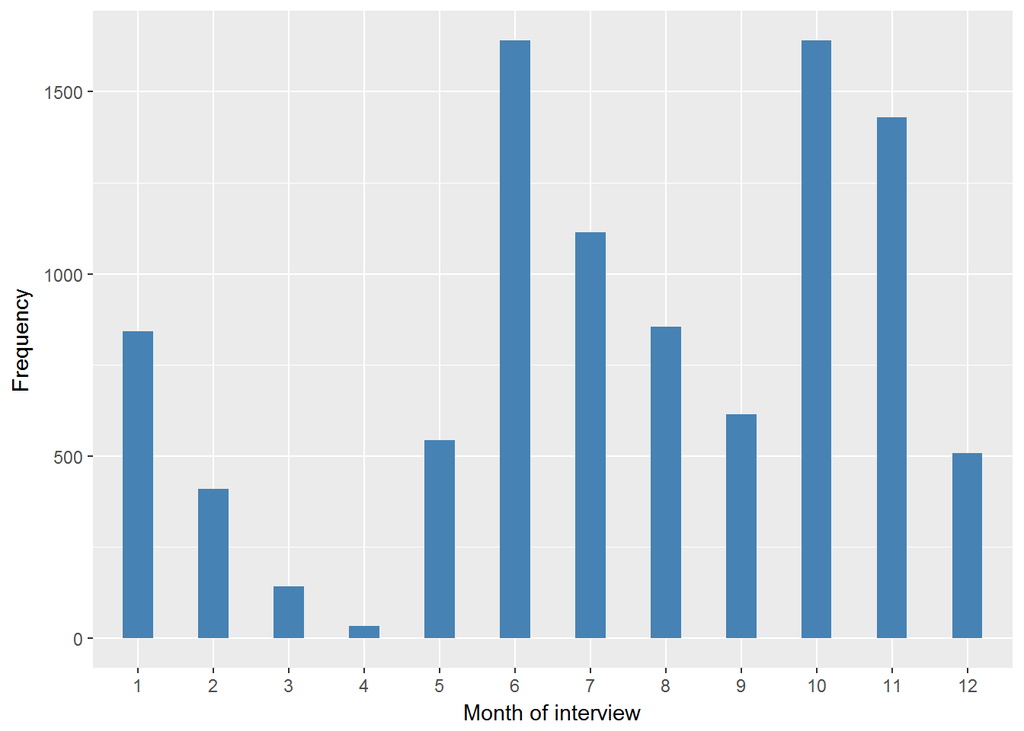

#### 2.1.3.4 Validation

|  | 1 | 2 | 3 | 4 | 5 | 6 | 7 | 8 | 9 | 10 | 11 | 12 |
| --- | --- | --- | --- | --- | --- | --- | --- | --- | --- | --- | --- | --- |
| BeforeH | 842 | 409 | 142 | 34 | 544 | 1640 | 1114 | 854 | 614 | 1640 | 1430 | 508 |
| AfterH | 842 | 409 | 142 | 34 | 544 | 1640 | 1114 | 854 | 614 | 1640 | 1430 | 508 |

### 2.1.4 Wave 4

#### 2.1.4.1 Study-specific variable description

The study-specific variable elected to be harmonised is:

- Name: `iintdatm`
- Label: `interview month - individual interview`
- Type of variable: `countinous`

```
## $values_table
##                  1       2      3      4     5       6       7       8
## Frequency  1565.00 1007.00 620.00 380.00 70.00 1212.00 1952.00 1302.00
## Percentage   14.16    9.11   5.61   3.44  0.63   10.97   17.67   11.78
##                 9     10     11      12
## Frequency  894.00 226.00 702.00 1120.00
## Percentage   8.09   2.05   6.35   10.14
##
## $n_table
##      Sample size Missing values
## [1,]       11050              0
```

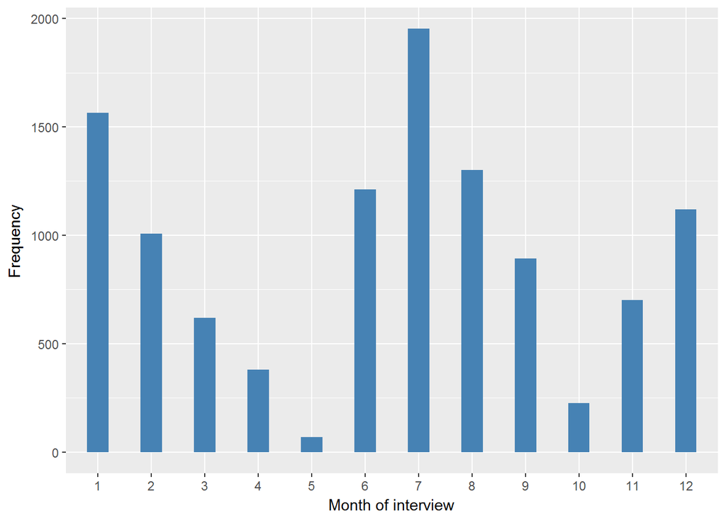

#### 2.1.4.2 Harmonisation algorithm

The harmonized variable is the same of the study-specific variable but the missing values have to be recoded as follows:

- `NA into 999`

**R script:**

```r
ELSA_ds_w4 <- tibble(id = ELSA_w4_yinter$id)
ELSA_ds_w4$mintw <- car::recode(ELSA_w4_yinter$iintdatm, "NA=999")
ELSA_ds_w4$mintw <- labelled(ELSA_ds_w4$mintw, labels = c(january = 1, february = 2,
    march = 3, april = 4, may = 5, june = 6, july = 7, august = 8, september = 9,
    october = 10, november = 11, december = 12, Missing = 999, `Do not know` = 998,
    Refuse = 997, `Not applicable` = 996, `Does not answer` = 995, `Not attempt not done` = 994,
    `Disable to measure` = 993, Impute = 992, `CAPI interviewer error` = 991))
```

#### 2.1.4.3 Statistics of the new harmonised variable

```
## $values_table
##                  1       2      3      4     5       6       7       8
## Frequency  1565.00 1007.00 620.00 380.00 70.00 1212.00 1952.00 1302.00
## Percentage   14.16    9.11   5.61   3.44  0.63   10.97   17.67   11.78
##                 9     10     11      12
## Frequency  894.00 226.00 702.00 1120.00
## Percentage   8.09   2.05   6.35   10.14
##
## $missing_values_table
##            991 992 993 994 995 996 997 998 999 NA
## Frequency    0   0   0   0   0   0   0   0   0  0
## Percentage   0   0   0   0   0   0   0   0   0  0
##
## $n_table
##      Sample size Missing values
## [1,]       11050              0
```

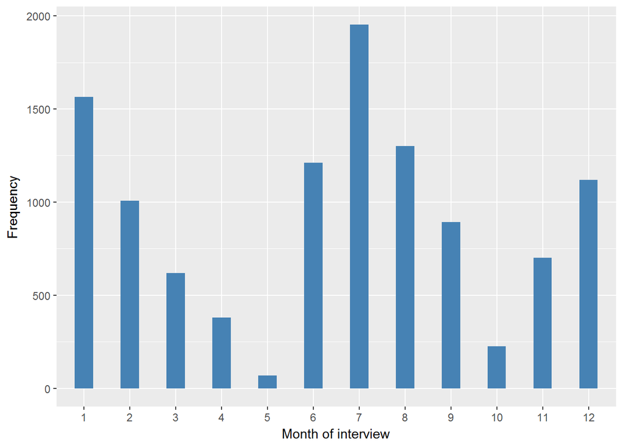

#### 2.1.4.4 Validation

|  | 1 | 2 | 3 | 4 | 5 | 6 | 7 | 8 | 9 | 10 | 11 | 12 |
| --- | --- | --- | --- | --- | --- | --- | --- | --- | --- | --- | --- | --- |
| BeforeH | 1565 | 1007 | 620 | 380 | 70 | 1212 | 1952 | 1302 | 894 | 226 | 702 | 1120 |
| AfterH | 1565 | 1007 | 620 | 380 | 70 | 1212 | 1952 | 1302 | 894 | 226 | 702 | 1120 |

### 2.1.5 Wave 5

#### 2.1.5.1 Study-specific variable description

The study-specific variable elected to be harmonised is:

- Name: `iintdatm`
- Label: `interview month - individual interview`
- Type of variable: `countinous`

```
## $values_table
##                  1       2      3   4      5    6       7      8      9
## Frequency  1177.00 1358.00 423.00 103 142.00 5.00 1142.00 936.00 1284.0
## Percentage   11.46   13.22   4.12   1   1.38 0.05   11.12   9.11   12.5
##                 10      11     12
## Frequency  1520.00 1368.00 816.00
## Percentage   14.79   13.32   7.94
##
## $n_table
##      Sample size Missing values
## [1,]       10274              0
```

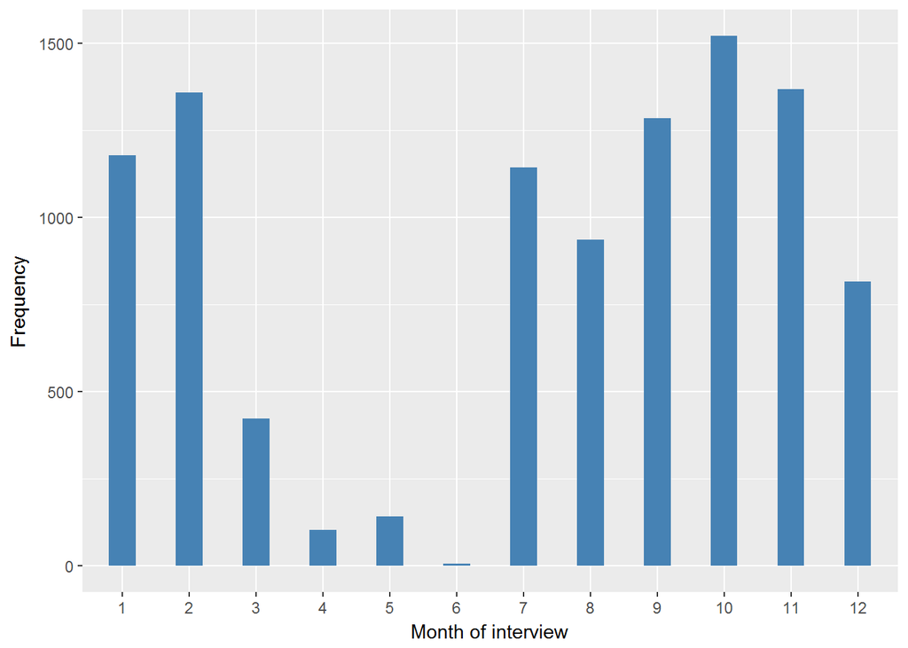

#### 2.1.5.2 Harmonisation algorithm

The harmonized variable is the same of the study-specific variable but the missing values have to be recoded as follows:

- `NA into 999`

**R script:**

```r
ELSA_ds_w5 <- tibble(id = ELSA_w5_minter$id)
ELSA_ds_w5$mintw <- car::recode(ELSA_w5_minter$iintdatm, "NA=999")
ELSA_ds_w5$mintw <- labelled(ELSA_ds_w5$mintw, labels = c(january = 1, february = 2,
    march = 3, april = 4, may = 5, june = 6, july = 7, august = 8, september = 9,
    october = 10, november = 11, december = 12, Missing = 999, `Do not know` = 998,
    Refuse = 997, `Not applicable` = 996, `Does not answer` = 995, `Not attempt not done` = 994,
    `Disable to measure` = 993, Impute = 992, `CAPI interviewer error` = 991))
```

#### 2.1.5.3 Statistics of the new harmonised variable

```
## $values_table
##                  1       2      3   4      5    6       7      8      9
## Frequency  1177.00 1358.00 423.00 103 142.00 5.00 1142.00 936.00 1284.0
## Percentage   11.46   13.22   4.12   1   1.38 0.05   11.12   9.11   12.5
##                 10      11     12
## Frequency  1520.00 1368.00 816.00
## Percentage   14.79   13.32   7.94
##
## $missing_values_table
##            991 992 993 994 995 996 997 998 999 NA
## Frequency    0   0   0   0   0   0   0   0   0  0
## Percentage   0   0   0   0   0   0   0   0   0  0
##
## $n_table
##      Sample size Missing values
## [1,]       10274              0
```

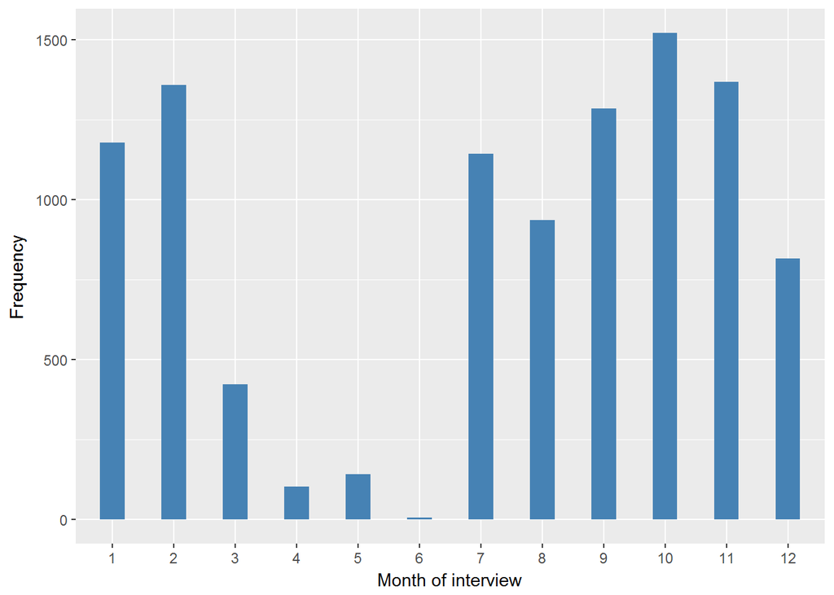

#### 2.1.5.4 Validation

|  | 1 | 2 | 3 | 4 | 5 | 6 | 7 | 8 | 9 | 10 | 11 | 12 |
| --- | --- | --- | --- | --- | --- | --- | --- | --- | --- | --- | --- | --- |
| BeforeH | 1177 | 1358 | 423 | 103 | 142 | 5 | 1142 | 936 | 1284 | 1520 | 1368 | 816 |
| AfterH | 1177 | 1358 | 423 | 103 | 142 | 5 | 1142 | 936 | 1284 | 1520 | 1368 | 816 |

### 2.1.6 Wave 6

#### 2.1.6.1 Study-specific variable description

The study-specific variable elected to be harmonised is:

- Name: `iintdatm`
- Label: `interview month - individual interview`
- Type of variable: `countinous`

```
## $values_table
##                 1      2     3      4     5      6       7      8       9
## Frequency  820.00 481.00 67.00 130.00 350.0 743.00 1101.00 1039.0 1099.00
## Percentage   7.74   4.54  0.63   1.23   3.3   7.01   10.39    9.8   10.37
##                 10      11     12
## Frequency  2190.00 1999.00 582.00
## Percentage   20.66   18.86   5.49
##
## $n_table
##      Sample size Missing values
## [1,]       10601              0
```

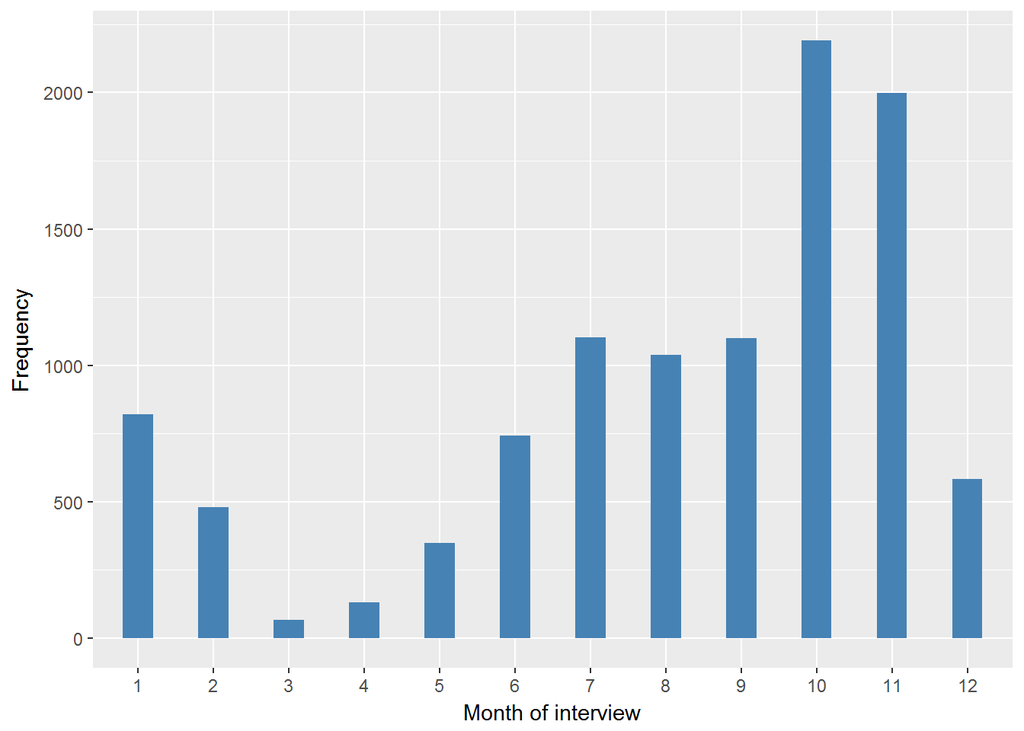

#### 2.1.6.2 Harmonisation algorithm

The harmonized variable is the same of the study-specific variable but the missing values have to be recoded as follows:

- `NA into 999`

**R script:**

```r
ELSA_ds_w6 <- tibble(id = ELSA_w6_minter$id)
ELSA_ds_w6$mintw <- car::recode(ELSA_w6_minter$iintdatm, "NA=999")
ELSA_ds_w6$mintw <- labelled(ELSA_ds_w6$mintw, labels = c(january = 1, february = 2,
    march = 3, april = 4, may = 5, june = 6, july = 7, august = 8, september = 9,
    october = 10, november = 11, december = 12, Missing = 999, `Do not know` = 998,
    Refuse = 997, `Not applicable` = 996, `Does not answer` = 995, `Not attempt not done` = 994,
    `Disable to measure` = 993, Impute = 992, `CAPI interviewer error` = 991))
```

#### 2.1.6.3 Statistics of the new harmonised variable

```
## $values_table
##                 1      2     3      4     5      6       7      8       9
## Frequency  820.00 481.00 67.00 130.00 350.0 743.00 1101.00 1039.0 1099.00
## Percentage   7.74   4.54  0.63   1.23   3.3   7.01   10.39    9.8   10.37
##                 10      11     12
## Frequency  2190.00 1999.00 582.00
## Percentage   20.66   18.86   5.49
##
## $missing_values_table
##            991 992 993 994 995 996 997 998 999 NA
## Frequency    0   0   0   0   0   0   0   0   0  0
## Percentage   0   0   0   0   0   0   0   0   0  0
##
## $n_table
##      Sample size Missing values
## [1,]       10601              0
```

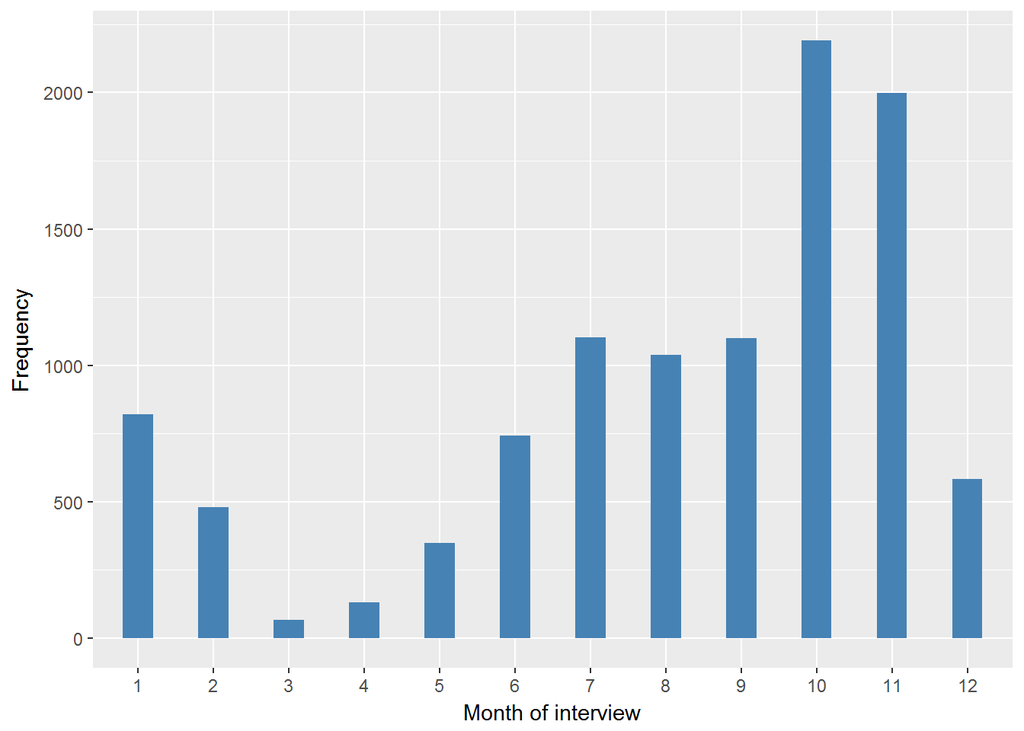

#### 2.1.6.4 Validation

|  | 1 | 2 | 3 | 4 | 5 | 6 | 7 | 8 | 9 | 10 | 11 | 12 |
| --- | --- | --- | --- | --- | --- | --- | --- | --- | --- | --- | --- | --- |
| BeforeH | 820 | 481 | 67 | 130 | 350 | 743 | 1101 | 1039 | 1099 | 2190 | 1999 | 582 |
| AfterH | 820 | 481 | 67 | 130 | 350 | 743 | 1101 | 1039 | 1099 | 2190 | 1999 | 582 |

### 2.1.7 Wave 7

#### 2.1.7.1 Study-specific variable description

The study-specific variable elected to be harmonised is:

- Name: `iintdatm`
- Label: `interview month - individual interview`
- Type of variable: `countinous`

```
## $values_table
##                 1      2      3      4     5      6       7      8       9
## Frequency  700.00 707.00 262.00 252.00 50.00 893.00 1166.00 806.00 1265.00
## Percentage   7.24   7.31   2.71   2.61  0.52   9.24   12.06   8.34   13.09
##                 10      11     12
## Frequency  1635.00 1190.00 740.00
## Percentage   16.91   12.31   7.66
##
## $n_table
##      Sample size Missing values
## [1,]        9666              0
```

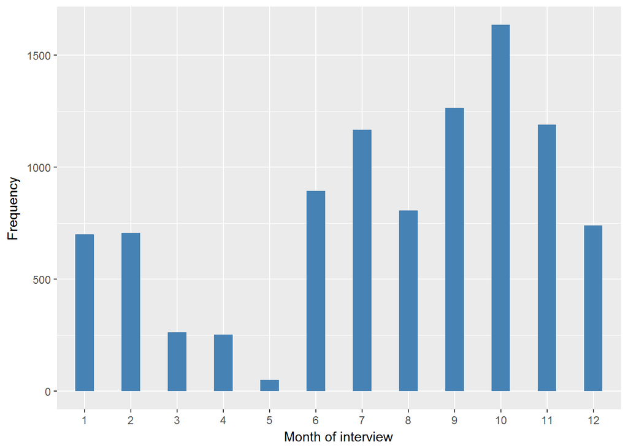

#### 2.1.7.2 Harmonisation algorithm

The harmonized variable is the same of the study-specific variable but the missing values have to be recoded as follows:

- `NA into 999`

**R script:**

```r
ELSA_ds_w7 <- tibble(id = ELSA_w7$id)
ELSA_ds_w7$mintw <- car::recode(ELSA_w7$iintdatm, "NA=999")
ELSA_ds_w7$mintw <- labelled(ELSA_ds_w7$mintw, labels = c(january = 1, february = 2,
    march = 3, april = 4, may = 5, june = 6, july = 7, august = 8, september = 9,
    october = 10, november = 11, december = 12, Missing = 999, `Do not know` = 998,
    Refuse = 997, `Not applicable` = 996, `Does not answer` = 995, `Not attempt not done` = 994,
    `Disable to measure` = 993, Impute = 992, `CAPI interviewer error` = 991))
```

#### 2.1.7.3 Statistics of the new harmonised variable

```
## $values_table
##                 1      2      3      4     5      6       7      8       9
## Frequency  700.00 707.00 262.00 252.00 50.00 893.00 1166.00 806.00 1265.00
## Percentage   7.24   7.31   2.71   2.61  0.52   9.24   12.06   8.34   13.09
##                 10      11     12
## Frequency  1635.00 1190.00 740.00
## Percentage   16.91   12.31   7.66
##
## $missing_values_table
##            991 992 993 994 995 996 997 998 999 NA
## Frequency    0   0   0   0   0   0   0   0   0  0
## Percentage   0   0   0   0   0   0   0   0   0  0
##
## $n_table
##      Sample size Missing values
## [1,]        9666              0
```

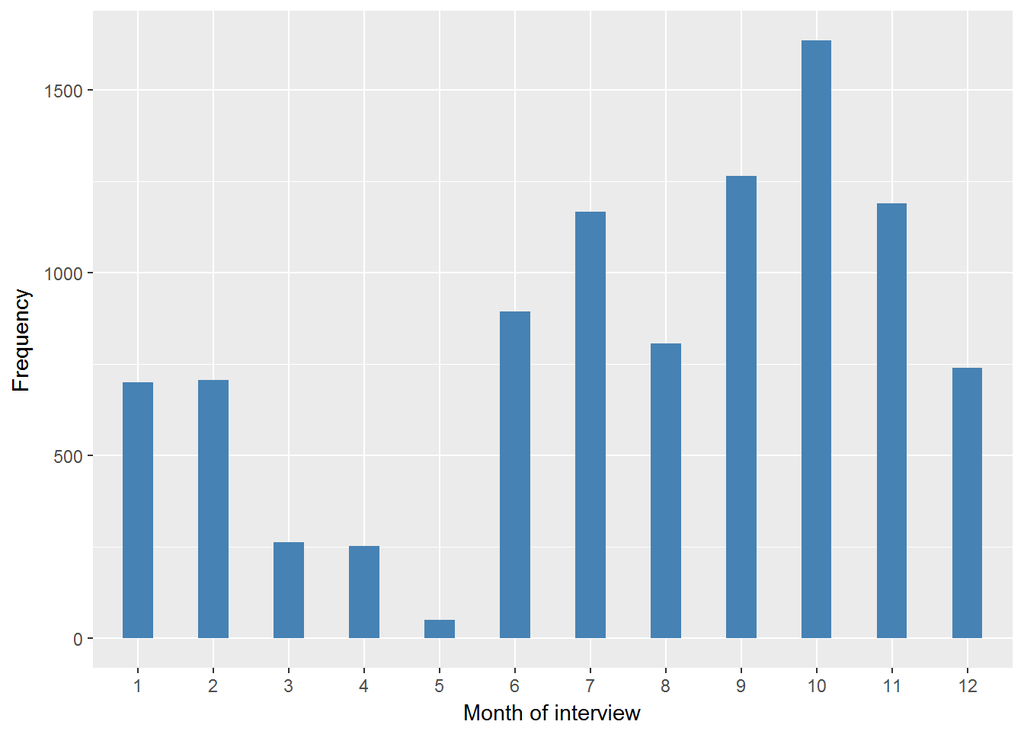

#### 2.1.7.4 Validation

|  | 1 | 2 | 3 | 4 | 5 | 6 | 7 | 8 | 9 | 10 | 11 | 12 |
| --- | --- | --- | --- | --- | --- | --- | --- | --- | --- | --- | --- | --- |
| BeforeH | 700 | 707 | 262 | 252 | 50 | 893 | 1166 | 806 | 1265 | 1635 | 1190 | 740 |
| AfterH | 700 | 707 | 262 | 252 | 50 | 893 | 1166 | 806 | 1265 | 1635 | 1190 | 740 |

# 3 Quality estimation